# Combining Predictors

## Key ideas

- combine classifiers by averaging/voting.
- combining classifiers imrpoves accuracy.
- Combining Classifiers reduces interpretability.
- Boosting, bagging and random forests are variantes of this theme.

## Basic intuition - majority vote

Suppose we have 5 completely independent classifiers

With 101 independent classifiers

- 99.9% majority vote accuracy

## Approaches for combining classifiers

- Bagging, boosting, random forests
- Usually combine similar classifiers
- Combining different classifiers
- Model stacking
- Model ensembling

## Example Wage data

```r
library(ISLR)
```

```r
data(Wage)
library(ggplot2)
library(caret)
Wage <- subset(Wage, select = -c(logwage))

# Create a building data set and validation set
inBuild <- createDataPartition(y=Wage$wage,
                              p=0.7, list=FALSE)
validation <- Wage[-inBuild,]; buildData <- Wage[inBuild,]

inTrain <- createDataPartition(y=buildData$wage,
                              p=0.7, list=FALSE)
training <- buildData[inTrain,]; testing <- buildData[-inTrain,]
```

## Wage data sets

Create training, test and validation sets

```r
dim(training)
```

```
## [1] 1474   11
```

```r
dim(testing)
```

```
## [1] 628  11
```

```r
dim(validation)
```

```
## [1] 898  11
```

Build two different models

```r
mod1 <- train(wage ~.,method="glm",data=training)
```

[output not shown]

[output cut: 19 more lines]

[output not shown]

```r
mod2 <- train(wage ~.,method="rf",
              data=training,
              trControl = trainControl(method="cv"),number=3)
```

Predict on the testing set

```r
pred1 <- predict(mod1,testing); pred2 <- predict(mod2,testing)
```

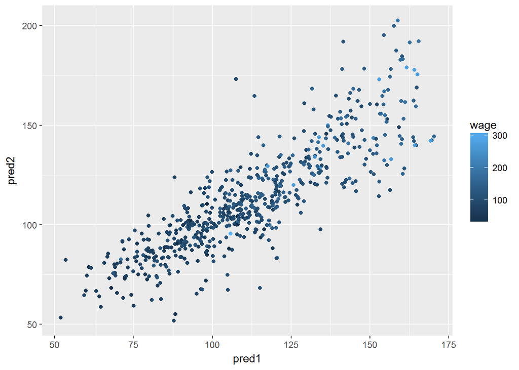

```r
qplot(pred1,pred2,colour=wage,data=testing)
```

Fit a model that combines predictors

```r
predDF <- data.frame(pred1,pred2,wage=testing$wage)
combModFit <- train(wage ~.,method="gam",data=predDF)
combPred <- predict(combModFit,predDF)
```

Testing errors

```r
sqrt(sum((pred1-testing$wage)^2))
```

```
## [1] 847.7929
```

```r
sqrt(sum((pred2-testing$wage)^2))
```

```
## [1] 881.6815
```

```r
sqrt(sum((combPred-testing$wage)^2))
```

```
## [1] 829.2931
```

Predict on validation data set

```r
pred1V <- predict(mod1,validation); pred2V <- predict(mod2,validation)
predVDF <- data.frame(pred1=pred1V,pred2=pred2V)
combPredV <- predict(combModFit,predVDF)
```

Evaluate on validation

```r
sqrt(sum((pred1V-validation$wage)^2))
```

```
## [1] 1018.504
```

```r
sqrt(sum((pred2V-validation$wage)^2))
```

```
## [1] 1052.696
```

```r
sqrt(sum((combPredV-validation$wage)^2))
```

```
## [1] 1011.501
```

Notes and further resources

- Even simple blending can be useful
- Typical model for binary/multiclass data
- Build an odd number of models
- Predict with each model
- Predict the class by majority vote
- This can get dramatically more complicated
- Simple blending in caret: caretEnsemble (use at your own risk!)
- Wikipedia ensemlbe learning